# Intro to R

Jeho Park

### Agenda

- About R
- R Basics
- Working With Data
- Hands-On Project
- Further Learning

### About R

- R is a language and environment for statistical computing and graphics.
- R is used in education, finance, software, medicine and more.
- The biggest draw of using R is the large amount of functionality through packages and its graphing capabilities. However, R can have shortcomings in its speed and the learning curve for non-programmers.

### About R - Sponsors/Users

[figure not shown]

### R Basics

### Getting Started - RConsole

- Upon opening RStudio, you will see the Console

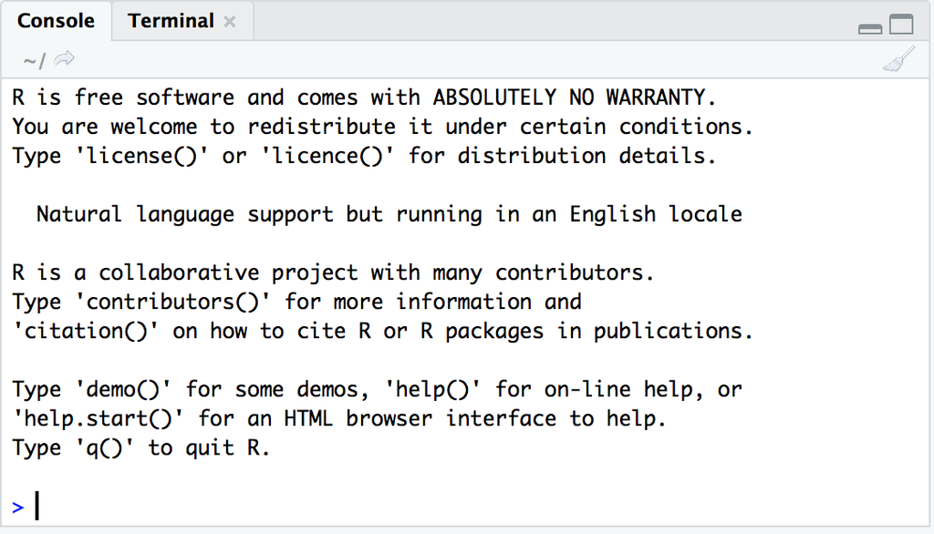

### Getting Started - RConsole

- You can perform some calculations by typing into it.

```r
2+2
```

```
[1] 4
```

### Getting Started - Variables

- You can also use variables and assign them values.

```r
x = 2
x+2
```

```
[1] 4
```

```r
# The "<-" operator is the same as "="
y <- x+1
x+y
```

```
[1] 5
```

### Getting Started - R Environment

- When you create a variable it will show up on the environment pane in RStudio

[figure not shown]

### R Basics - Arithmetic Operators

- Operators are symbols that use some input and *operate* on them.
- Arithmetic operators are our common mathematical symbols.

```r
x*x # Multiplication
```

```
[1] 4
```

```r
x/x # Division
```

```
[1] 1
```

```r
x^3 # Exponentiation
```

```
[1] 8
```

### R Basics - Logical Operators

- Logical operators output either True or False

```r
2 < 5  # Less Than
```

```
[1] TRUE
```

```r
x >= 2 # Greater Than Or Equal To
```

```
[1] TRUE
```

### R Basics - Logical Operators

```r
x == 1 # Equal to. NOTE: This is different from "="
```

```
[1] FALSE
```

```r
x != x # Not Equal to
```

```
[1] FALSE
```

### R Basics - Data Types

- R can work with more than just numbers.

```r
class("hello, world!") # The class function returns the data type of a variable or value.
```

```
[1] "character"
```

```r
class(x == y)
```

```
[1] "logical"
```

### R Basics - Vectors

- Up until now, we have been working with single numbers and variables also known as scalars.
- In R, there are also vectors which are sequences of values.

```r
a <- c(1,2,3)
b <- c(3,2,1)
a+b # Most operations on a vector will be element-wise
```

```
[1] 4 4 4
```

### R Basics - Built-In Functions

- Functions take an input and produce an output. R contains many functions that are built-in, some of which we have already seen [class(), c()]

```r
abs(-5) # Absolute Value
```

```
[1] 5
```

```r
sqrt(4) # Square Root
```

```
[1] 2
```

### R Basics - Built-In Functions - 2

```r
sum(a)  # Sum
```

```
[1] 6
```

```r
toupper("hello") # To Upper Case
```

```
[1] "HELLO"
```

### R Basics - Built-In Functions - 3

```r
sd(a) # Standard Deviation
```

```
[1] 1
```

```r
cor(a,b) # Correlation
```

```
[1] -1
```

### R Basics - Libraries and Packages

- R is known for its community and its libraries/packages
- Packages are collections of R functions, data, and compiled code in a well-defined format. The directory where packages are stored is called the library.
- We will install the dplyr package, a popular package for data manipulation
- `install.packages('dplyr')`

```r
library('dplyr')
```

### R Basics - Help

- With all these packages and functions you may forget how to use one or need to remember which one to use.

```r
# This will search for usage of the hist function
?hist
```

```r
# This will search packages and functions about histograms
??histogram
```

### Exercise 1

- Review of some basic R features
- Open ./exercises/intro/exercise_1.Rmd

### Working with Data

### Working with Data - DataFrames

- A data frame is used for storing data tables. It is a list of vectors of equal length.

```r
names <- c("John", "Kim", "Terry")
ages  <- c(21, 34, 16)
male  <- c(TRUE, FALSE, TRUE)
data.frame(names, ages, male)
```

```
  names ages  male
1  John   21  TRUE
2   Kim   34 FALSE
3 Terry   16  TRUE
```

### Working with Data - DataFrames - Datasets

- R's datasets package has some built in datasets that we will be using.
  - The CO2 data frame has 84 rows and 5 columns of data from an experiment on the cold tolerance of the grass species Echinochloa crus-galli.

```r
help(CO2)
```

- You can use '$' to access a vector (column/feature/etc) of a dataframe

### Working with Data - Data Exploration - Head

```r
# The head function shows the first few entries in a dataframe.
head(CO2)
```

```
  Plant   Type  Treatment conc uptake
1   Qn1 Quebec nonchilled   95   16.0
2   Qn1 Quebec nonchilled  175   30.4
3   Qn1 Quebec nonchilled  250   34.8
4   Qn1 Quebec nonchilled  350   37.2
5   Qn1 Quebec nonchilled  500   35.3
6   Qn1 Quebec nonchilled  675   39.2
```

### Working with Data - Data Exploration - Summary

```r
# The summary function shows summary statistics.
summary(CO2)
```

```
     Plant             Type         Treatment       conc
 Qn1    : 7   Quebec     :42   nonchilled:42   Min.   :  95
 Qn2    : 7   Mississippi:42   chilled   :42   1st Qu.: 175
 Qn3    : 7                                    Median : 350
 Qc1    : 7                                    Mean   : 435
 Qc3    : 7                                    3rd Qu.: 675
 Qc2    : 7                                    Max.   :1000
 (Other):42
     uptake
 Min.   : 7.70
 1st Qu.:17.90
 Median :28.30
 Mean   :27.21
 3rd Qu.:37.12
 Max.   :45.50
```

### Working with Data - Data Visualization

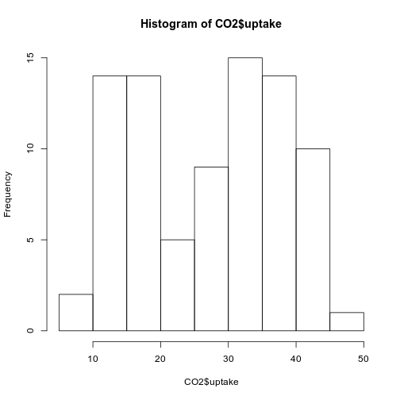

```r
hist(CO2$uptake) # Use help function for more plotting options
```

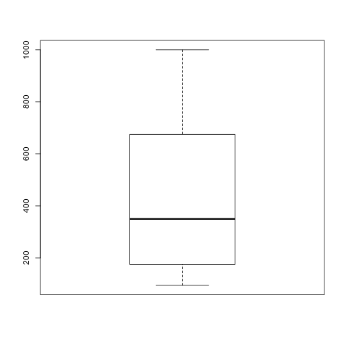

```r
boxplot(CO2$conc)
```

```r
plot(CO2$uptake, CO2$conc)
```

[output not shown]

### Working with Data - Data Visualization - Boxplot

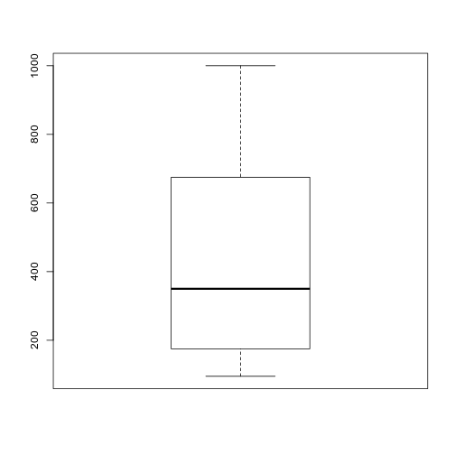

```r
boxplot(CO2$conc)
```

```r
plot(CO2$uptake, CO2$conc)
```

[output not shown]

```r
plot(CO2$uptake, CO2$conc)
```

[output not shown]

### Exercise 2

- Review of datasets and data visualization
- Open ./exercises/intro/exercise_2.Rmd

### Working with Data - Data Manipulation

- Dplyr is the most common package used for data exploration and transformation
- Dplyr functions: filter, select, arrange, mutate, summarise (plus group_by)

```r
head(filter(CO2, Treatment=='nonchilled'))
```

```
  Plant   Type  Treatment conc uptake
1   Qn1 Quebec nonchilled   95   16.0
2   Qn1 Quebec nonchilled  175   30.4
3   Qn1 Quebec nonchilled  250   34.8
4   Qn1 Quebec nonchilled  350   37.2
5   Qn1 Quebec nonchilled  500   35.3
6   Qn1 Quebec nonchilled  675   39.2
```

### Working with Data - Data Manipulation - Select

- `select` will output only the columns that you choose

```r
head(select(CO2, Plant, conc, uptake), 3)
```

```
  Plant conc uptake
1   Qn1   95   16.0
2   Qn1  175   30.4
3   Qn1  250   34.8
```

### Working with Data - Data Manipulation - Chaining

- You can chain/pipe dplyr functions together
  - The infix (or pipe) operator '%>%' will feed the resulting object into the 1st paramater of the next function

```r
x <- select(filter(CO2, Treatment=='nonchilled'), Plant, conc, uptake) # OR
y <- CO2 %>% filter(Treatment=='nonchilled') %>% select(Plant, conc, uptake)
x == y
```

```
      Plant conc uptake
 [1,]  TRUE TRUE   TRUE
 [2,]  TRUE TRUE   TRUE
 [3,]  TRUE TRUE   TRUE
 [4,]  TRUE TRUE   TRUE
 [5,]  TRUE TRUE   TRUE
 [6,]  TRUE TRUE   TRUE
 [7,]  TRUE TRUE   TRUE
 [8,]  TRUE TRUE   TRUE
 [9,]  TRUE TRUE   TRUE
[10,]  TRUE TRUE   TRUE
[11,]  TRUE TRUE   TRUE
[12,]  TRUE TRUE   TRUE
[13,]  TRUE TRUE   TRUE
[14,]  TRUE TRUE   TRUE
```

[output cut: 28 more lines]

### Working with Data - Data Manipulation - Arrange

- `arrange()` sorts rows by a column

```r
# Use desc() to sort descending
CO2 %>% arrange(desc(uptake)) %>% head(3)
```

```
  Plant   Type  Treatment conc uptake
1   Qn3 Quebec nonchilled 1000   45.5
2   Qn2 Quebec nonchilled 1000   44.3
3   Qn3 Quebec nonchilled  675   43.9
```

### Working with Data - Data Manipulation - Mutate

- `mutate()` creates new variables

```r
CO2 %>% mutate(conc_L = conc / 1000) %>% head()
```

```
  Plant   Type  Treatment conc uptake conc_L
1   Qn1 Quebec nonchilled   95   16.0  0.095
2   Qn1 Quebec nonchilled  175   30.4  0.175
3   Qn1 Quebec nonchilled  250   34.8  0.250
4   Qn1 Quebec nonchilled  350   37.2  0.350
5   Qn1 Quebec nonchilled  500   35.3  0.500
6   Qn1 Quebec nonchilled  675   39.2  0.675
```

### Working with Data - Data Manipulation - Summarise

- `group_by()` and `summarise()` work together to aggregate variables

```r
CO2 %>% group_by(Type) %>% summarise(avg_uptake = mean(uptake))
```

```
# A tibble: 2 x 2
  Type        avg_uptake
  <fct>            <dbl>
1 Quebec            33.5
2 Mississippi       20.9
```

### Working with Data - Data Manipulation - Tips

- In datasets with a lot of columns you can select all columns but selected ones by using the '-' operator `select(CO2, -Plant)`
- When aggregating data you need an aggregate function such as mean, median, n (number of rows in a group), sum, etc.
- If your data has missing values, you need to add the parameter `na.rm = TRUE`, this will skip any missing values.
- When working with data, the data manipulation process often takes more time than the analysis.

### Exercise 3

- Review of some data manipulation functions in dplyr
- Open ./exercises/intro/exercise_3.Rmd

### Further Learning - Beginner/Intermediate

- Beginner/Intermediate Topics
  - User Defined Functions
  - Control Structures
  - Statistical Methods
  - Data Cleaning
  - Data Visualization Libraries (ggplot2, plotly)
    - https://plot.ly/r/dashboard/

### Further Learning - Advanced

- Advanced Topics
  - Deep Learning
  - Functional Programming
  - Object Oriented Programming
  - Debugging Tools
  - Performance

### Hands-On Project

### Hands-On Project

- In this workshop we have been using the console but when working on a project you will generally use the editor so you can save your scripts. This helps anyone reproduce your findings.
- When using a script, you must run your code either all at once (Run All) or Line-by-Line

### Hands-On Project - Reading the Data

- Download the data to your computer at http://bit.ly/r-hands-on-s2018
- You can import the data to R either by code or by clicking Import Dataset on the Environment Tab

[output not shown]